# Homework 5

Hajra Shahab

### Preamble: Loading packages and data

```r
library(rpart)
library(randomForest)
library(pROC)
library(gbm)
library(factoextra)
options(scipen = 4)
load(file = "hw5dat.Rda")
```

##### In this assignment we will continue to work with the `marketing` dataset from Homework 4. Run the code chunk below to load the data.

```r
# Read in the marketing data
marketing <- read.csv("bank-full.csv")

set.seed(981)

# Upsample the data to artifically overcome sample imbalance
marketing.more.idx <- sample(which(marketing$y == "yes"), 15000, replace = TRUE)
marketing.upsample <- rbind(marketing,
                            marketing[marketing.more.idx, ])

# Trim job strings to 5 characters
# marketing.upsample <- transform(marketing.upsample, job = strtrim(job, 5))

# Randomly select 20% of the data to be held out for model validation
test.indexes <- sample(1:nrow(marketing.upsample),
                       round(0.2 * nrow(marketing.upsample)))
train.indexes <- setdiff(1:nrow(marketing.upsample), test.indexes)

# Just pull the covariates available to marketers (cols 1:8) and the outcome (col 17)
marketing.train <- marketing.upsample[train.indexes, c(1:8, 17)]
marketing.test <- marketing.upsample[test.indexes, c(1:8, 17)]
```

### Problem 1: Random forests

##### (a) Use the `randomForest` command to fit a random forest to `marketing.train` (this may take a minute or two to run). Call your fit `marketing.rf`. Show a print-out of your random Forest fit. This print-out contains a confusion matrix. Are the predicted classes given as the rows or columns of this table?

```r
set.seed(1)

marketing.rf <- randomForest(as.factor(y) ~ ., data = marketing.train, mtry = 3, importance=TRUE)
marketing.rf
```

```
##
## Call:
##  randomForest(formula = as.factor(y) ~ ., data = marketing.train,      mtry = 3, importance = TRUE)
##                Type of random forest: classification
##                      Number of trees: 500
## No. of variables tried at each split: 3
##
##         OOB estimate of  error rate: 16.26%
## Confusion matrix:
##        no   yes class.error
## no  29155  2782   0.0871090
## yes  5048 11184   0.3109906
```

##### (b) Construct a variable importance plot of your random forest fit. Which variables turn out to be the most important?

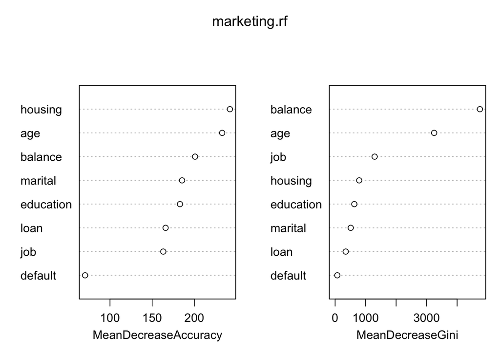

```r
varImpPlot(marketing.rf, newdata = marketing.test)
```

```r
importance(marketing.rf)
```

```
##                   no       yes MeanDecreaseAccuracy MeanDecreaseGini
## age        34.346115 214.32138            232.89804       3246.40775
## job        -5.257269 156.99657            163.14532       1296.00172
## marital   -12.037342 183.93934            185.39102        512.00592
## education  -9.086660 173.08352            182.92139        629.68510
## default    -6.826400  82.58845             70.52985         72.12687
## balance     7.473340 205.07207            200.79290       4748.18558
## housing    34.347308 239.68639            242.09468        790.08984
## loan      -18.763598 186.59405            165.89220        347.47906
```

According to Increase in Node Purity (Mean Decrease Gini): Balance and Age are the most important According to % Increase in MSE (Mean Decrease Accuracy): Housing and Age are the most important

##### (c) Use the `predict` command to obtain probability estimates on the test data. Produce the confusion matrix with a cutoff threshold of 0.3 and compute the following metrics: (1) accuracy, (2) sensitivity (a.k.a. recall), (3) specificity, (4) precision (a.k.a. positive predictive value), and (5) negative predictive value. Then recreate the `marketing.pruned` tree from HW4 (you can hardcode the `cp` value you obtained from HW4 when pruning the tree; no need to derive it from the cptable / plot again) and compute the same five metrics at cutoff threshold of 0.3. Compare the metrics of the two models and comment on your observation.

```r
marketing.prob <- predict(marketing.rf, marketing.test, type = "prob")
score.prob <- marketing.prob[, "yes"]

pred.class <- ifelse(score.prob >= 0.3, "yes", "no")

predicted <- factor(pred.class, levels = c("yes", "no"))
observed <- factor(marketing.test$y, levels = c("yes", "no"))
conf.mat <- table(predicted, observed)

#accuracy
(conf.mat[1,1] + conf.mat[2,2]) / (conf.mat[1,1] + conf.mat[1,2] + conf.mat[2,1] + conf.mat[2,2])
```

```
## [1] 0.8457067
```

```r
#sensitivity
conf.mat[2,2] / (conf.mat[1,2] + conf.mat[2,2])
```

```
## [1] 0.825047
```

```r
# specificity
conf.mat[1,1] / (conf.mat[1,1] + conf.mat[2,1])
```

```
## [1] 0.8863692
```

```r
#precision (positive predictive value)
conf.mat[2,2] / (conf.mat[2,2] + conf.mat[2,1])
```

```
## [1] 0.9346007
```

```r
#negative predictive value
conf.mat[1,1] / (conf.mat[1,1] + conf.mat[1,2])
```

```
## [1] 0.7202083
```

```r
marketing.full <- rpart(y ~ ., data = marketing.train,
                        control = rpart.control(minsplit=100, cp=0.002))
marketing.pruned <- prune(marketing.full, cp = 0.002033021)
print(marketing.pruned)
```

```
## n= 48169
##
## node), split, n, loss, yval, (yprob)
##       * denotes terminal node
##
##    1) root 48169 16232 no (0.6630198 0.3369802)
##      2) housing=yes 24469  5979 no (0.7556500 0.2443500)
##        4) age< 60.5 24301  5849 no (0.7593103 0.2406897) *
##        5) age>=60.5 168    38 yes (0.2261905 0.7738095) *
##      3) housing=no 23700 10253 no (0.5673840 0.4326160)
##        6) balance< 105.5 5412  1455 no (0.7311530 0.2688470)
##         12) age< 60.5 5200  1315 no (0.7471154 0.2528846)
##           24) job=admin.,blue-collar,entrepreneur,housemaid,management,retired,self-employed,services,technician,unemployed,unknown 5015  1206 no (0.7595214 0.2404786) *
##           25) job=student 185    76 yes (0.4108108 0.5891892) *
##         13) age>=60.5 212    72 yes (0.3396226 0.6603774) *
##        7) balance>=105.5 18288  8798 no (0.5189195 0.4810805)
##         14) age< 60.5 16562  7531 no (0.5452844 0.4547156)
##           28) age>=29.5 13880  5746 no (0.5860231 0.4139769)
##             56) job=blue-collar,entrepreneur,housemaid,self-employed,unknown 3417  1005 no (0.7058824 0.2941176) *
##             57) job=admin.,management,retired,services,student,technician,unemployed 10463  4741 no (0.5468795 0.4531205)
##              114) loan=yes 1005   233 no (0.7681592 0.2318408) *
##              115) loan=no 9458  4508 no (0.5233665 0.4766335)
##                230) education=primary,secondary 4481  1901 no (0.5757643 0.4242357)
##                  460) job=management,retired,services,technician 2972  1147 no (0.6140646 0.3859354) *
##                  461) job=admin.,student,unemployed 1509   754 no (0.5003313 0.4996687)
##                    922) balance>=5034.5 121    30 no (0.7520661 0.2479339) *
##                    923) balance< 5034.5 1388   664 yes (0.4783862 0.5216138)
##                     1846) balance< 915 642   284 no (0.5576324 0.4423676) *
##                     1847) balance>=915 746   306 yes (0.4101877 0.5898123) *
##                231) education=tertiary,unknown 4977  2370 yes (0.4761905 0.5238095)
##                  462) marital=married 2763  1353 no (0.5103149 0.4896851)
##                    924) balance>=11388 86    25 no (0.7093023 0.2906977) *
##                    925) balance< 11388 2677  1328 no (0.5039223 0.4960777)
##                     1850) balance< 2035 1784   838 no (0.5302691 0.4697309) *
##                     1851) balance>=2035 893   403 yes (0.4512878 0.5487122) *
##                  463) marital=divorced,single 2214   960 yes (0.4336043 0.5663957)
##                    926) balance< 196.5 150    52 no (0.6533333 0.3466667) *
##                    927) balance>=196.5 2064   862 yes (0.4176357 0.5823643) *
##           29) age< 29.5 2682   897 yes (0.3344519 0.6655481)
##             58) loan=yes 238    81 no (0.6596639 0.3403361) *
##             59) loan=no 2444   740 yes (0.3027823 0.6972177) *
##         15) age>=60.5 1726   459 yes (0.2659328 0.7340672) *
```

```r
marketing.pruned.prob <- predict(marketing.pruned, marketing.test, type = "prob")
score.pruned.prob <- marketing.pruned.prob[, "yes"]

pred.class <- ifelse(score.pruned.prob >= 0.3, "yes", "no")

predicted <- factor(pred.class, levels = c("yes", "no"))
observed <- factor(marketing.test$y, levels = c("yes", "no"))
conf.mat2 <- table (predicted, observed)

#accuracy
(conf.mat2[1,1] + conf.mat2[2,2]) / (conf.mat2[1,1] + conf.mat2[1,2] + conf.mat2[2,1] + conf.mat2[2,2])
```

```
## [1] 0.6939877
```

```r
#sensitivity
conf.mat2[2,2] / (conf.mat2[1,2] + conf.mat2[2,2])
```

```
## [1] 0.8032561
```

```r
# specificity
conf.mat2[1,1] / (conf.mat2[1,1] + conf.mat2[2,1])
```

```
## [1] 0.4789253
```

```r
#precision (positive predictive value)
conf.mat2[2,2] / (conf.mat2[2,2] + conf.mat2[2,1])
```

```
## [1] 0.7521107
```

```r
#negative predictive value
conf.mat2[1,1] / (conf.mat2[1,1] + conf.mat2[1,2])
```

```
## [1] 0.5529311
```

Overall, the random forest fit at a cutoff of 0.3 performs better than pruned tree. We can observe significant improvement across all metrics especially around accuracy, specificity, precision, and negative predictive value.

##### (d) Use the `roc` function from the `pROC` package to create two ROC objects, one for the random forest and the other for the pruned tree (see online documentation [here](https://www.rdocumentation.org/packages/pROC/versions/1.17.0.1/topics/roc)). Use `plot()` on the ROC object to plot the ROC curve for the random forest (see online documentation [here](https://www.rdocumentation.org/packages/pROC/versions/1.17.0.1/topics/plot.roc)). Also set `col = "blue"` for the ROC curve of the random forest. Then on the same plot, overlay the ROC curve for the pruned tree (use `add = TRUE` to overlay the curve on the previous plot, and use `"black"` as the color). Calculate the AUC for both methods (can you find it in the ROC objects?). Do we do better with random forests than with a single tree? Is the random forest strictly performing better in every region on the plot? Are most of the gains at high or low values of Specificity? We knew from HW4 that the high-sensitivity, low-specificity region is most relevant in this marketing setting. Does it correspond to the region where we observe most of the gains in the ROC plot?

**Note:** If you step through your code line-by-line, make sure you **highlight both `plot()` lines** and run them **together at the same time**. If you run the second `plot()` line with `add = TRUE` by itself you’ll get an error.

```r
#ROC for random forest
roc.1 <- roc(marketing.test$y, score.prob, auc = TRUE)
#ROC for pruned
roc.2 <- roc(marketing.test$y, score.pruned.prob, auc=TRUE)
```

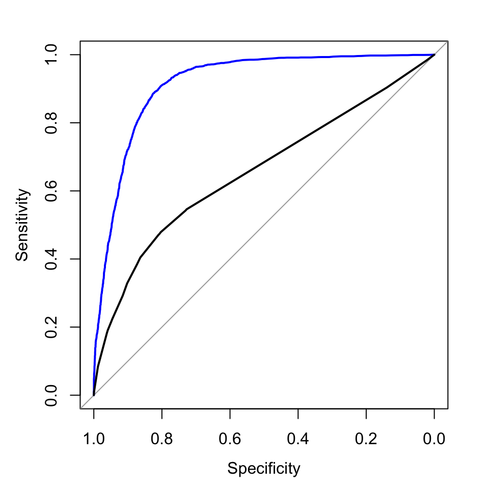

```r
plot(roc.1, col = "blue")
plot(roc.2, col="black",add = TRUE)
```

```r
#calculate AUC for ROC1
roc.1$auc
```

```
## Area under the curve: 0.9166
```

```r
#calculate AUC for ROC2
roc.2$auc
```

```
## Area under the curve: 0.6576
```

### Problem 2: Boosted Trees for Classification

##### In Lab 5 we learned how to use `gbm` function to fit a boosted tree model in the regression context. In this problem, we are going to see how to use `gbm` in the context of classification tasks. It takes a long time to run `gbm` on large datasets, so in order to shorten the runtime we will only use a subset of the training data to fit the boosted tree model. Run the code below.

```r
set.seed(1)
subset = sample(nrow(marketing.train), 15000)
marketing.train.boost = marketing.train[subset,]
```

##### (a) For classification with binary outcomes, `gbm` requires the values of the outcome variable to be either 0 or 1, so we need to convert the outcome variable `y` (yes-no) into 0-1 outcomes. Recode the `y` variable in `marketing.train.boost` as 0-1 outcomes, with 0 for “no” and 1 for “yes”.

```r
#marketing.train.boost <- ifelse(marketing$y == "yes", 1, 0)
```

##### (b) Use the `gbm` command to fit a boosted tree model on the `marketing.train.boost` dataset. For binary classification problems like ours, set `distribution = "bernoulli"`. Set the learning rate to `0.05` and allow for trees up to depth `4`. We want to use `gbm`’s built-in cross-validation functionality to choose the optimal number of trees, so let’s grow up to `20000` trees and also set `cv.folds = 5`. Name your model `marketing.boost`.

> **ALERT:** This command takes a LONG TIME to run (it took me 10 minutes). I’ve set the `cache=TRUE` option for the code chunk below so when you knit your Rmd file it reruns only when you make changes to this code chunk. BE PATIENT when you run this command and when you knit the Rmd file!

```r
#set.seed(4)

#marketing.boost <- gbm(y ~., data = marketing.train.boost, distribution = "bernoulli", n.trees = 20000, interaction.depth = 4, shrinkage = 0.05, cv.folds = 5, verbose = F)
```

##### (c) Use the `gbm.perf` function to obtain the optimal number of trees for the `marketing.boost` model (set `method = "cv"`). What is the optimal number of trees? In addition to returning the optimal number of trees, the `gbm.perf` function also generates a plot. Interpret the plot (Google “gbm.perf plot” for hints).

```r
#gbm.perf(marketing.boost, method = "cv")
```

##### (d) Use the `predict` command to obtain probability estimates on the test data (refer to documentation for coding hints). Make sure you set the `n.trees` to the optimal number of trees obtained above. Create the ROC object for the boosted tree model. Then plot the ROC curves of the random forest (color it “blue”) and the boosted tree model (color it “red”) on the same plot. Compare the AUC for these two methods. Do we do better with the boosted tree model than with the random forest? Is one model strictly performing better than the other model in every region on the plot? Given a specificity level of, say, 0.9, which model should we pick? How about given a specificity level of, say, 0.4? Which model performs better in the region that is most relevant in this marketing setting?

**Note:** Given the seeds I set before fitting the models, the ROC plot I get looks like the following where the two curves cross each other (although in the actual plot the gap between the two curves isn’t nearly as pronounced). However, due to the randomness in the process, your plot may or may not look the same as mine. If your code is correct but you don’t get the crossing curves, don’t sweat. Just answer the questions based on the ROC plot you get.

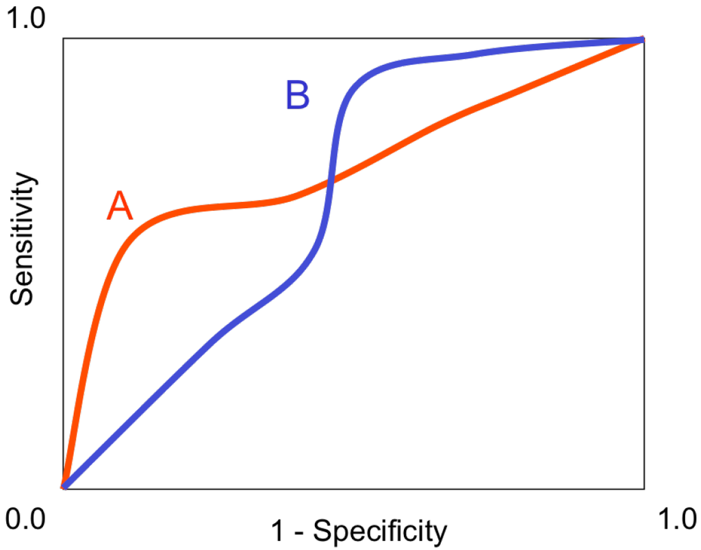

```r
#pred.prob1 <- predict(marketing.boost, newdata = marketing.test, n.trees = 14261, type = "response")

#ROC for random forest
#roc.1 <- roc(marketing.test$y, score.prob, auc = TRUE)

#ROC for boosted tree model
#roc.2 <- roc(marketing.test$y, pred.prob1, auc = TRUE)

#plot(roc.1, col = "blue")
#plot(roc.2, col="red", add = TRUE)

#calculate AUC for ROC1
#roc.1$auc

#calculate AUC for ROC2
#roc.2$auc
```

### Problem 3: Clustering US States by Violent Crime Rates

We will use the built-in R dataset `USArrests` which contains statistics in arrests per 100,000 residents for assault, murder, and rape in each of the 50 US states in 1973. It also includes the percentage of the population living in urban areas in each state. `View()` the dataset and read the help with `?USArrests` to find out more about the dataset.

##### (a) You saw in Lab 4 that we need to standardized the data before applying methods such as KNN that builds upon distances between observations. K-means clustering is yet another such method that often requires the input data to be standardized. Use the appropriate function to standardize the data and save the resulting data frame as `USArrests.scaled`.

```r
USArrests.scaled <- scale(USArrests)
USArrests.scaled
```

```
##                     Murder     Assault    UrbanPop         Rape
## Alabama         1.24256408  0.78283935 -0.52090661 -0.003416473
## Alaska          0.50786248  1.10682252 -1.21176419  2.484202941
## Arizona         0.07163341  1.47880321  0.99898006  1.042878388
## Arkansas        0.23234938  0.23086801 -1.07359268 -0.184916602
## California      0.27826823  1.26281442  1.75892340  2.067820292
## Colorado        0.02571456  0.39885929  0.86080854  1.864967207
## Connecticut    -1.03041900 -0.72908214  0.79172279 -1.081740768
## Delaware       -0.43347395  0.80683810  0.44629400 -0.579946294
## Florida         1.74767144  1.97077766  0.99898006  1.138966691
## Georgia         2.20685994  0.48285493 -0.38273510  0.487701523
## Hawaii         -0.57123050 -1.49704226  1.20623733 -0.110181255
## Idaho          -1.19113497 -0.60908837 -0.79724965 -0.750769945
## Illinois        0.59970018  0.93883125  1.20623733  0.295524916
## Indiana        -0.13500142 -0.69308401 -0.03730631 -0.024769429
## Iowa           -1.28297267 -1.37704849 -0.58999237 -1.060387812
## Kansas         -0.41051452 -0.66908525  0.03177945 -0.345063775
## Kentucky        0.43898421 -0.74108152 -0.93542116 -0.526563903
## Louisiana       1.74767144  0.93883125  0.03177945  0.103348309
## Maine          -1.30593210 -1.05306531 -1.00450692 -1.434064548
## Maryland        0.80633501  1.55079947  0.10086521  0.701231086
## Massachusetts  -0.77786532 -0.26110644  1.34440885 -0.526563903
## Michigan        0.99001041  1.01082751  0.58446551  1.480613993
## Minnesota      -1.16817555 -1.18505846  0.03177945 -0.676034598
## Mississippi     1.90838741  1.05882502 -1.48810723 -0.441152078
## Missouri        0.27826823  0.08687549  0.30812248  0.743936999
## Montana        -0.41051452 -0.74108152 -0.86633540 -0.515887425
## Nebraska       -0.80082475 -0.82507715 -0.24456358 -0.505210947
## Nevada          1.01296983  0.97482938  1.06806582  2.644350114
## New Hampshire  -1.30593210 -1.36504911 -0.65907813 -1.252564419
## New Jersey     -0.08908257 -0.14111267  1.62075188 -0.259651949
## New Mexico      0.82929443  1.37080881  0.30812248  1.160319648
## New York        0.76041616  0.99882813  1.41349461  0.519730957
## North Carolina  1.19664523  1.99477641 -1.41902147 -0.547916860
## North Dakota   -1.60440462 -1.50904164 -1.48810723 -1.487446939
## Ohio           -0.11204199 -0.60908837  0.65355127  0.017936483
## Oklahoma       -0.27275797 -0.23710769  0.16995096 -0.131534211
## Oregon         -0.66306820 -0.14111267  0.10086521  0.861378259
## Pennsylvania   -0.34163624 -0.77707965  0.44629400 -0.676034598
## Rhode Island   -1.00745957  0.03887798  1.48258036 -1.380682157
## South Carolina  1.51807718  1.29881255 -1.21176419  0.135377743
## South Dakota   -0.91562187 -1.01706718 -1.41902147 -0.900240639
## Tennessee       1.24256408  0.20686926 -0.45182086  0.605142783
## Texas           1.12776696  0.36286116  0.99898006  0.455672088
## Utah           -1.05337842 -0.60908837  0.99898006  0.178083656
## Vermont        -1.28297267 -1.47304350 -2.31713632 -1.071064290
## Virginia        0.16347111 -0.17711080 -0.17547783 -0.056798864
## Washington     -0.86970302 -0.30910395  0.51537975  0.530407436
## West Virginia  -0.47939280 -1.07706407 -1.83353601 -1.273917376
## Wisconsin      -1.19113497 -1.41304662  0.03177945 -1.113770203
## Wyoming        -0.22683912 -0.11711392 -0.38273510 -0.601299251
## attr(,"scaled:center")
##   Murder  Assault UrbanPop     Rape
##    7.788  170.760   65.540   21.232
## attr(,"scaled:scale")
##    Murder   Assault  UrbanPop      Rape
##  4.355510 83.337661 14.474763  9.366385
```

##### (b) Use the `kmeans` function to cluster the data for `K` being 2, 3, 4, and 5 respectively. Set `nstart = 20` for `kmeans`. Then use the function `fviz_cluster` (refer to online documentation for syntax; you only need to supply the `object` and the `data` arguments) to visualize the result (one plot for each `K` value). Compare the clusters generated given different `K` values. What do you observe? Are the clusters given larger K nested within the clusters given smaller K?

**Note:** the axes of the plots generated by `fviz_cluster` are the first and the second principal components (discussed in Lecture 12). As we saw / will see in Lecture 12, the first principal component represents the overall rates of serious crimes, whereas the second principal component represents the level of urbanization. The sign of the axes of your plots may be flipped/inverted, i.e. negative direction corresponds to higher crime rate / level of urbanization (this is a common artifact of PCA; you don’t need to correct it here; we are just providing this information to help you interpret the plots).

```r
#For K=2
km.out2 <- kmeans(USArrests.scaled, 2, nstart=20)
km.out2
```

```
## K-means clustering with 2 clusters of sizes 30, 20
##
## Cluster means:
##      Murder    Assault   UrbanPop       Rape
## 1 -0.669956 -0.6758849 -0.1317235 -0.5646433
## 2  1.004934  1.0138274  0.1975853  0.8469650
##
## Clustering vector:
##        Alabama         Alaska        Arizona       Arkansas     California
##              2              2              2              1              2
##       Colorado    Connecticut       Delaware        Florida        Georgia
##              2              1              1              2              2
##         Hawaii          Idaho       Illinois        Indiana           Iowa
##              1              1              2              1              1
##         Kansas       Kentucky      Louisiana          Maine       Maryland
##              1              1              2              1              2
##  Massachusetts       Michigan      Minnesota    Mississippi       Missouri
##              1              2              1              2              2
##        Montana       Nebraska         Nevada  New Hampshire     New Jersey
##              1              1              2              1              1
##     New Mexico       New York North Carolina   North Dakota           Ohio
##              2              2              2              1              1
##       Oklahoma         Oregon   Pennsylvania   Rhode Island South Carolina
##              1              1              1              1              2
##   South Dakota      Tennessee          Texas           Utah        Vermont
##              1              2              2              1              1
##       Virginia     Washington  West Virginia      Wisconsin        Wyoming
##              1              1              1              1              1
##
## Within cluster sum of squares by cluster:
## [1] 56.11445 46.74796
##  (between_SS / total_SS =  47.5 %)
##
## Available components:
##
## [1] "cluster"      "centers"      "totss"        "withinss"     "tot.withinss"
## [6] "betweenss"    "size"         "iter"         "ifault"
```

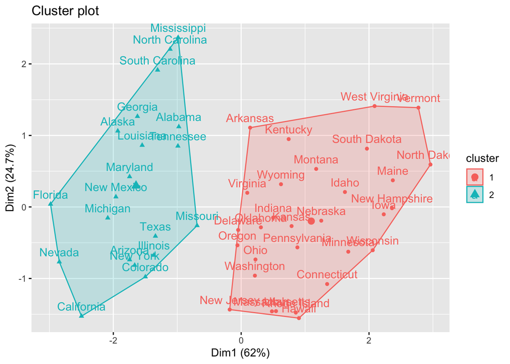

```r
fviz2 <- fviz_cluster(km.out2, data = USArrests.scaled)
fviz2
```

```r
#For K=3
set.seed(1)
km.out3 <- kmeans(USArrests.scaled, 3, nstart=20)
km.out3
```

```
## K-means clustering with 3 clusters of sizes 13, 17, 20
##
## Cluster means:
##       Murder    Assault   UrbanPop       Rape
## 1 -0.9615407 -1.1066010 -0.9301069 -0.9667633
## 2 -0.4469795 -0.3465138  0.4788049 -0.2571398
## 3  1.0049340  1.0138274  0.1975853  0.8469650
##
## Clustering vector:
##        Alabama         Alaska        Arizona       Arkansas     California
##              3              3              3              2              3
##       Colorado    Connecticut       Delaware        Florida        Georgia
##              3              2              2              3              3
##         Hawaii          Idaho       Illinois        Indiana           Iowa
##              2              1              3              2              1
##         Kansas       Kentucky      Louisiana          Maine       Maryland
##              2              1              3              1              3
##  Massachusetts       Michigan      Minnesota    Mississippi       Missouri
##              2              3              1              3              3
##        Montana       Nebraska         Nevada  New Hampshire     New Jersey
##              1              1              3              1              2
##     New Mexico       New York North Carolina   North Dakota           Ohio
##              3              3              3              1              2
##       Oklahoma         Oregon   Pennsylvania   Rhode Island South Carolina
##              2              2              2              2              3
##   South Dakota      Tennessee          Texas           Utah        Vermont
##              1              3              3              2              1
##       Virginia     Washington  West Virginia      Wisconsin        Wyoming
##              2              2              1              1              2
##
## Within cluster sum of squares by cluster:
## [1] 11.95246 19.62285 46.74796
##  (between_SS / total_SS =  60.0 %)
##
## Available components:
##
## [1] "cluster"      "centers"      "totss"        "withinss"     "tot.withinss"
## [6] "betweenss"    "size"         "iter"         "ifault"
```

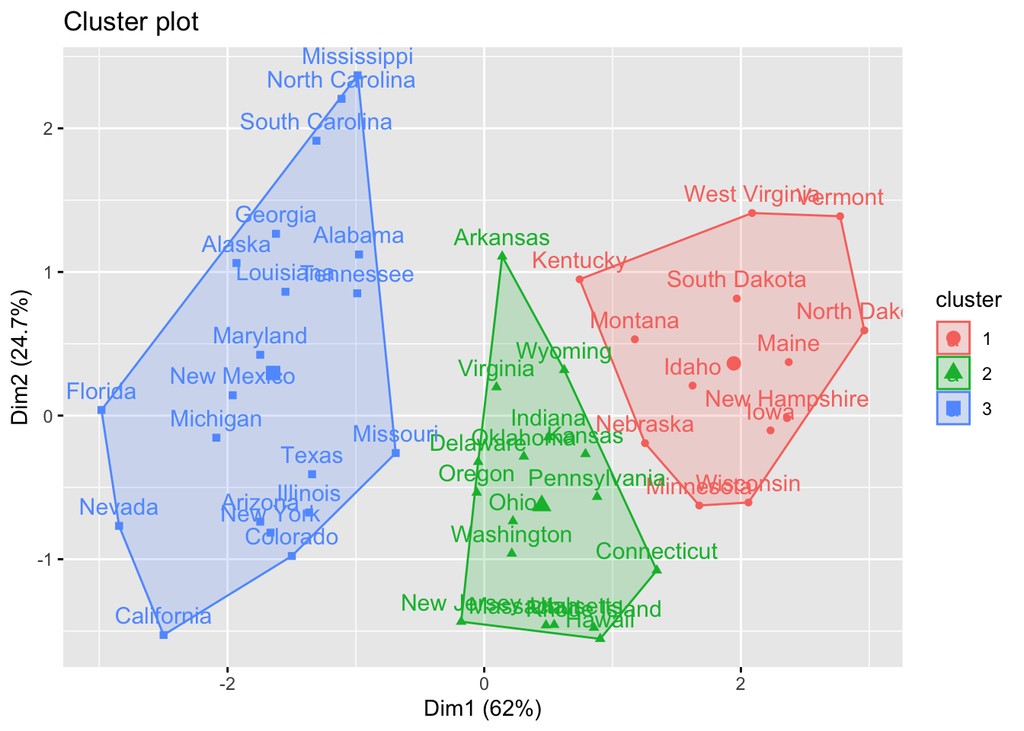

```r
fviz3 <- fviz_cluster(km.out3, data = USArrests.scaled)
fviz3
```

```r
#For K=4
set.seed(1)
km.out4 <- kmeans(USArrests.scaled, 4, nstart=20)
km.out4
```

```
## K-means clustering with 4 clusters of sizes 13, 13, 16, 8
##
## Cluster means:
##       Murder    Assault   UrbanPop        Rape
## 1 -0.9615407 -1.1066010 -0.9301069 -0.96676331
## 2  0.6950701  1.0394414  0.7226370  1.27693964
## 3 -0.4894375 -0.3826001  0.5758298 -0.26165379
## 4  1.4118898  0.8743346 -0.8145211  0.01927104
##
## Clustering vector:
##        Alabama         Alaska        Arizona       Arkansas     California
##              4              2              2              4              2
##       Colorado    Connecticut       Delaware        Florida        Georgia
##              2              3              3              2              4
##         Hawaii          Idaho       Illinois        Indiana           Iowa
##              3              1              2              3              1
##         Kansas       Kentucky      Louisiana          Maine       Maryland
##              3              1              4              1              2
##  Massachusetts       Michigan      Minnesota    Mississippi       Missouri
##              3              2              1              4              2
##        Montana       Nebraska         Nevada  New Hampshire     New Jersey
##              1              1              2              1              3
##     New Mexico       New York North Carolina   North Dakota           Ohio
##              2              2              4              1              3
##       Oklahoma         Oregon   Pennsylvania   Rhode Island South Carolina
##              3              3              3              3              4
##   South Dakota      Tennessee          Texas           Utah        Vermont
##              1              4              2              3              1
##       Virginia     Washington  West Virginia      Wisconsin        Wyoming
##              3              3              1              1              3
##
## Within cluster sum of squares by cluster:
## [1] 11.952463 19.922437 16.212213  8.316061
##  (between_SS / total_SS =  71.2 %)
##
## Available components:
##
## [1] "cluster"      "centers"      "totss"        "withinss"     "tot.withinss"
## [6] "betweenss"    "size"         "iter"         "ifault"
```

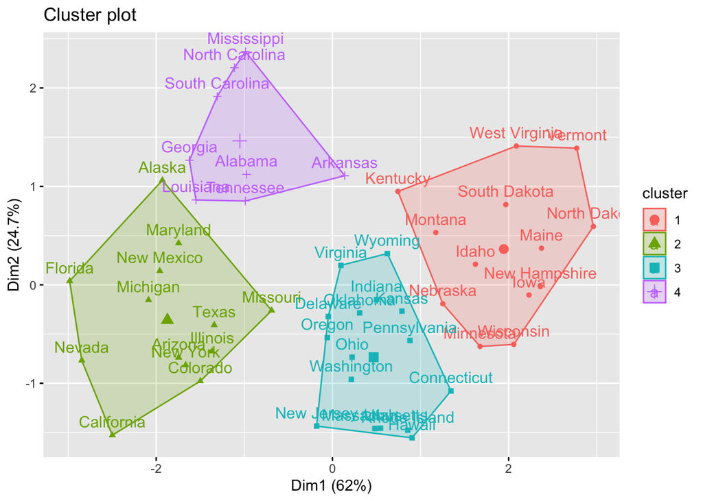

```r
fviz4 <- fviz_cluster(km.out4, data = USArrests.scaled)
fviz4
```

```r
#For K=5
set.seed(1)
km.out5 <- kmeans(USArrests.scaled, 5, nstart=20)
km.out5
```

```
## K-means clustering with 5 clusters of sizes 10, 12, 11, 7, 10
##
## Cluster means:
##       Murder    Assault   UrbanPop        Rape
## 1 -0.6286291 -0.4086988  0.9506200 -0.38883734
## 2  0.7298036  1.1188219  0.7571799  1.32135653
## 3 -0.1642225 -0.3658283 -0.2822467 -0.11697538
## 4  1.5803956  0.9662584 -0.7775109  0.04844071
## 5 -1.1727674 -1.2078573 -1.0045069 -1.10202608
##
## Clustering vector:
##        Alabama         Alaska        Arizona       Arkansas     California
##              4              2              2              3              2
##       Colorado    Connecticut       Delaware        Florida        Georgia
##              2              1              1              2              4
##         Hawaii          Idaho       Illinois        Indiana           Iowa
##              1              5              2              3              5
##         Kansas       Kentucky      Louisiana          Maine       Maryland
##              3              3              4              5              2
##  Massachusetts       Michigan      Minnesota    Mississippi       Missouri
##              1              2              5              4              3
##        Montana       Nebraska         Nevada  New Hampshire     New Jersey
##              3              3              2              5              1
##     New Mexico       New York North Carolina   North Dakota           Ohio
##              2              2              4              5              1
##       Oklahoma         Oregon   Pennsylvania   Rhode Island South Carolina
##              3              3              1              1              4
##   South Dakota      Tennessee          Texas           Utah        Vermont
##              5              4              2              1              5
##       Virginia     Washington  West Virginia      Wisconsin        Wyoming
##              3              1              5              5              3
##
## Within cluster sum of squares by cluster:
## [1]  9.326266 18.257332  7.788275  6.128432  7.443899
##  (between_SS / total_SS =  75.0 %)
##
## Available components:
##
## [1] "cluster"      "centers"      "totss"        "withinss"     "tot.withinss"
## [6] "betweenss"    "size"         "iter"         "ifault"
```

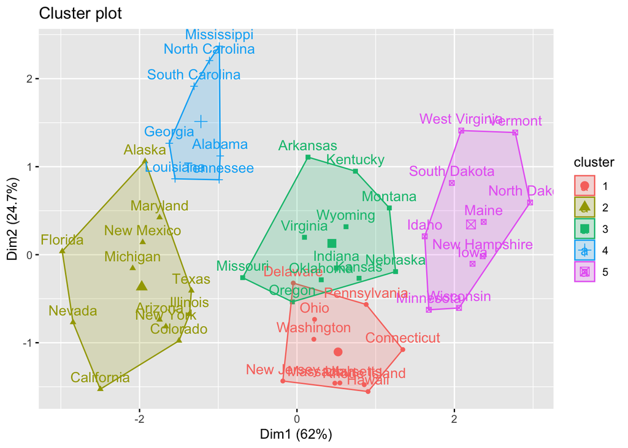

```r
fviz5 <- fviz_cluster(km.out5, data = USArrests.scaled)
fviz5
```

##### (c) A popular way to decide the “optimal” number of clusters is called the elbow method, where we plot the Within-Cluster-Sum-of-Squares (abbrev. WCSS, a within-cluster similarity measure that’s similar to Within-Cluster-Variation) against increasing `k` values and visually examine at which `k` value the reduction in WCSS starts to slow down (Google “elbow method for clustering” for numerous visual examples). Let’s use the function `fviz_nbclust` (refer to online documentation for syntax) to produce the plot and make sure you set the right `method` argument. What is the optimal `k` for this dataset? Explain.

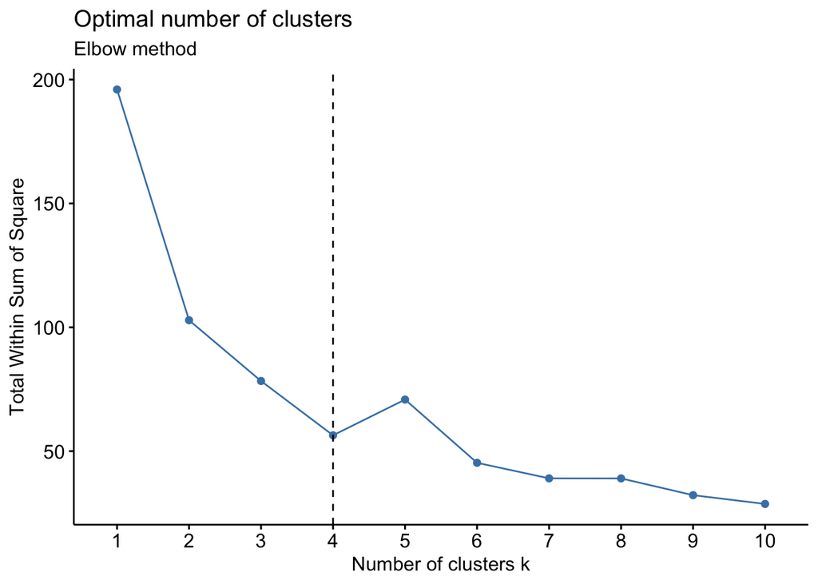

```r
fviz_nbclust(USArrests.scaled, kmeans, method = "wss") + geom_vline(xintercept = 4, linetype = 2)+ labs(subtitle = "Elbow method")
```

Optimal number of clusters: 4 as it appears to be the bend in the knee (or elbow). We define clusters such that the total intra-cluster variation (known as total within-cluster variation or total within-cluster sum of square) is minimized. The total within-cluster sum of square (wss) measures the compactness of the clustering and we want it to be as small as possible. Source: https://uc-r.github.io/kmeans_clustering

##### (d) From the model with the optimal `k` you identified above, display the locations of the cluster centers in the feature space (hint: check out documentation for `kmeans` function). Note that the values of the centers are in the standardized scale. Tranform them back to the original scale of the data (see [here](https://stackoverflow.com/questions/10287545/backtransform-scale-for-plotting) for hints) and interpret the differences across the clusters based on their center values.

```r
USArrests.scaled * attr(USArrests.scaled, 'scaled:scale') + attr(USArrests.scaled, 'scaled:center')
```

```
##                   Murder    Assault   UrbanPop       Rape
## Alabama         13.20000  76.871414   5.519186  65.490547
## Alaska         213.08407  31.598925  69.774407  44.500000
## Arizona         66.57688  14.228942  80.000000  12.330267
## Arkansas        23.40827 190.000000  11.176318 155.349483
## California       9.00000  83.818940  15.449008  95.471209
## Colorado       172.90299  24.967869 242.497770  38.700000
## Connecticut     50.62493   4.612476  77.000000   3.076468
## Delaware        17.17192 238.000000  25.412161 122.428632
## Florida         15.40000  94.066540  12.139067  82.026273
## Georgia        354.67454  25.754605 138.863752  25.800000
## Hawaii          57.27157   1.267618  83.000000   7.308104
## Idaho           10.07537 120.000000  13.764653 108.192589
## Illinois        10.40000  79.129360  13.041778  69.817653
## Indiana        159.50930  14.740309 167.650979  21.000000
## Iowa            46.96927   1.790252  57.000000   3.169471
## Kansas          17.38696 115.000000  21.529659 142.003192
## Kentucky         9.70000  54.813020   3.713764  57.918112
## Louisiana      316.40685  30.025454 173.408425  22.200000
## Maine           46.63694   3.201364  51.000000   1.541918
## Maryland        28.78444 300.000000  22.176742 229.198958
## Massachusetts    4.40000  61.760546  13.643586  57.918112
## Michigan       253.26515  30.699799 219.467989  35.100000
## Minnesota       48.63094   2.626466  66.000000   4.843525
## Mississippi     39.10669 259.000000   7.293816 133.995418
## Missouri         9.00000  66.797502   9.130030  76.308312
## Montana        136.54868  14.290746  98.561634  16.400000
## Nebraska        53.94825   4.194368  62.000000   5.587549
## Nevada          30.71986 252.000000  31.235915 391.133953
## New Hampshire    2.10000  45.781237   4.917379  47.409426
## New Jersey     163.33607  19.910284 305.829671  18.800000
## New Mexico      77.54384  13.758571  70.000000  12.841784
## New York        28.35435 254.000000  34.471334 214.073162
## North Carolina  13.00000  94.413917   1.607438  57.609033
## North Dakota    37.05267   7.097736  46.744625   7.300000
## Ohio            63.91822   5.135110  75.000000   7.866123
## Oklahoma        18.67724 151.000000  22.823826 159.798247
## Oregon           4.90000  63.497427   8.227319  78.008246
## Pennsylvania   142.28883  13.953573 207.953098  14.900000
## Rhode Island    50.95726   7.957333  87.000000   1.774425
## South Carolina  35.45089 279.000000   9.882151 182.042064
## South Dakota     3.80000  50.818193   1.607438  52.509230
## Tennessee      274.31238  23.169617 133.106307  26.900000
## Texas           81.86416   9.368445  80.000000   9.772684
## Utah            11.36565 120.000000  30.588831 185.601075
## Vermont          2.20000  44.218044  -2.304310  50.036598
## Virginia       184.38330  19.573112 156.136089  20.700000
## Washington      52.95125   6.441695  73.000000  10.098195
## West Virginia   16.74182  81.000000   4.058397  64.594706
## Wisconsin        2.60000  45.086484   7.926416  49.418440
## Wyoming        151.85576  20.135066 138.863752  15.600000
## attr(,"scaled:center")
##   Murder  Assault UrbanPop     Rape
##    7.788  170.760   65.540   21.232
## attr(,"scaled:scale")
##    Murder   Assault  UrbanPop      Rape
##  4.355510 83.337661 14.474763  9.366385
```

```r
kmeans(USArrests.scaled, centers = 4, iter.max = 10, nstart = 1)
```

```
## K-means clustering with 4 clusters of sizes 13, 13, 8, 16
##
## Cluster means:
##       Murder    Assault   UrbanPop        Rape
## 1 -0.9615407 -1.1066010 -0.9301069 -0.96676331
## 2  0.6950701  1.0394414  0.7226370  1.27693964
## 3  1.4118898  0.8743346 -0.8145211  0.01927104
## 4 -0.4894375 -0.3826001  0.5758298 -0.26165379
##
## Clustering vector:
##        Alabama         Alaska        Arizona       Arkansas     California
##              3              2              2              3              2
##       Colorado    Connecticut       Delaware        Florida        Georgia
##              2              4              4              2              3
##         Hawaii          Idaho       Illinois        Indiana           Iowa
##              4              1              2              4              1
##         Kansas       Kentucky      Louisiana          Maine       Maryland
##              4              1              3              1              2
##  Massachusetts       Michigan      Minnesota    Mississippi       Missouri
##              4              2              1              3              2
##        Montana       Nebraska         Nevada  New Hampshire     New Jersey
##              1              1              2              1              4
##     New Mexico       New York North Carolina   North Dakota           Ohio
##              2              2              3              1              4
##       Oklahoma         Oregon   Pennsylvania   Rhode Island South Carolina
##              4              4              4              4              3
##   South Dakota      Tennessee          Texas           Utah        Vermont
##              1              3              2              4              1
##       Virginia     Washington  West Virginia      Wisconsin        Wyoming
##              4              4              1              1              4
##
## Within cluster sum of squares by cluster:
## [1] 11.952463 19.922437  8.316061 16.212213
##  (between_SS / total_SS =  71.2 %)
##
## Available components:
##
## [1] "cluster"      "centers"      "totss"        "withinss"     "tot.withinss"
## [6] "betweenss"    "size"         "iter"         "ifault"
```